# Regresion - Entrega 2

2022-10-06

# Regresion - MARIAJOSE MURILLO

En el 2021 fueron las elecciones presidenciales, cuya segunda vuelta fue disputada por Keiko Fujimori y Pedro Castillo, donde resulto ganador el segundo, sin embargo, que variables pudieron influenciar en su victoria?

- “dep”: departamento del Peru
- “prov”: provincia del Peru
- “habil”: electores habiles - tambien se usara como variable de control

#### Variable dependiente:

“casti”: votos a Pedro Castillo

#### Variables independientes:

“gas”: personas con acceso a gas GLP

“sis”: personas con acceso al seguro de salud

“acsedu”: personas con acceso a la educacion

Primero veamos los contenidos:

```r
rm(list = ls())
knitr::knit_hooks$set(inline = as.character)

gitLink="https://github.com/MajoMurillo/Estadistica2---Trabajo/blob/main/dataCGSE.xlsx?raw=true"
dataCGSE=rio::import(gitLink)

library(magrittr)
dataCGSE%>%
    rmarkdown::paged_table()
```

|  | Dep | Prov | casti | gas | sis | acsedu | habil |
| --- | --- | --- | --- | --- | --- | --- | --- |
| 1 | Amazonas | Chachapoyas | 25980 | 10641 | 3286 | 18668 | 62110 |
| 2 | Amazonas | Bagua | 8374 | 9917 | 54088 | 24452 | 20917 |
| 3 | Amazonas | Bongara | 15671 | 4659 | 18057 | 7536 | 40752 |
| 4 | Amazonas | Condorcanqui | 14024 | 1536 | 33802 | 16281 | 38273 |
| 5 | Amazonas | Luya | 12606 | 6339 | 36541 | 13777 | 35017 |
| 6 | Amazonas | Rodriguez de Mendoza | 7967 | 3781 | 20815 | 8693 | 22886 |
| 7 | Amazonas | Utcubamba | 36540 | 16078 | 80664 | 34334 | 86231 |
| 8 | Ancash | Huaraz | 2325 | 30307 | 90834 | 55893 | 5817 |
| 9 | Ancash | Aija | 5056 | 478 | 4542 | 1871 | 10921 |
| 10 | Ancash | Antonio Raymondi | 2860 | 776 | 11048 | 4966 | 5968 |

[output cut: 186 more lines]

Vemos que toda las variables son numericas a excepcion de “departamento” y “provincia” por lo que primero se optara por una **regresion lineal**

```r
str(dataCGSE)
```

```
## 'data.frame':    196 obs. of  7 variables:
##  $ Dep   : chr  "Amazonas" "Amazonas" "Amazonas" "Amazonas" ...
##  $ Prov  : chr  "Chachapoyas" "Bagua" "Bongara" "Condorcanqui" ...
##  $ casti : num  25980 8374 15671 14024 12606 ...
##  $ gas   : num  10641 9917 4659 1536 6339 ...
##  $ sis   : num  3286 54088 18057 33802 36541 ...
##  $ acsedu: num  18668 24452 7536 16281 13777 ...
##  $ habil : num  62110 20917 40752 38273 35017 ...
```

Nuestra primera hipotesis es: **A nivel provincial, la cantidad de personas que votaron por Pedro Castillo estara afectada por si usan gas GLP**

```r
library(knitr)
library(modelsummary)

h1=formula(casti~gas)

rl1=lm(h1, data = dataCGSE)

model1=list('OLS votantes de Castillo (1)'=rl1)
modelsummary(model1, title = "Tabla 1: Resumen de Regresion Lineal",
             stars = TRUE,
             output = "kableExtra")
```

Tabla 1: Resumen de Regresion Lineal

|  | OLS votantes de Castillo (1) |
| --- | --- |
| (Intercept) | 43534.236*** |
|  | (10500.202) |
| gas | 0.026 |
|  | (0.078) |
| Num.Obs. | 196 |
| R2 | 0.001 |
| R2 Adj. | −0.005 |
| AIC | 5217.7 |
| BIC | 5227.5 |
| Log.Lik. | −2605.852 |
| F | 0.112 |
| RMSE | 143806.91 |

+ p < 0.1, * p < 0.05, ** p < 0.01, *** p < 0.001

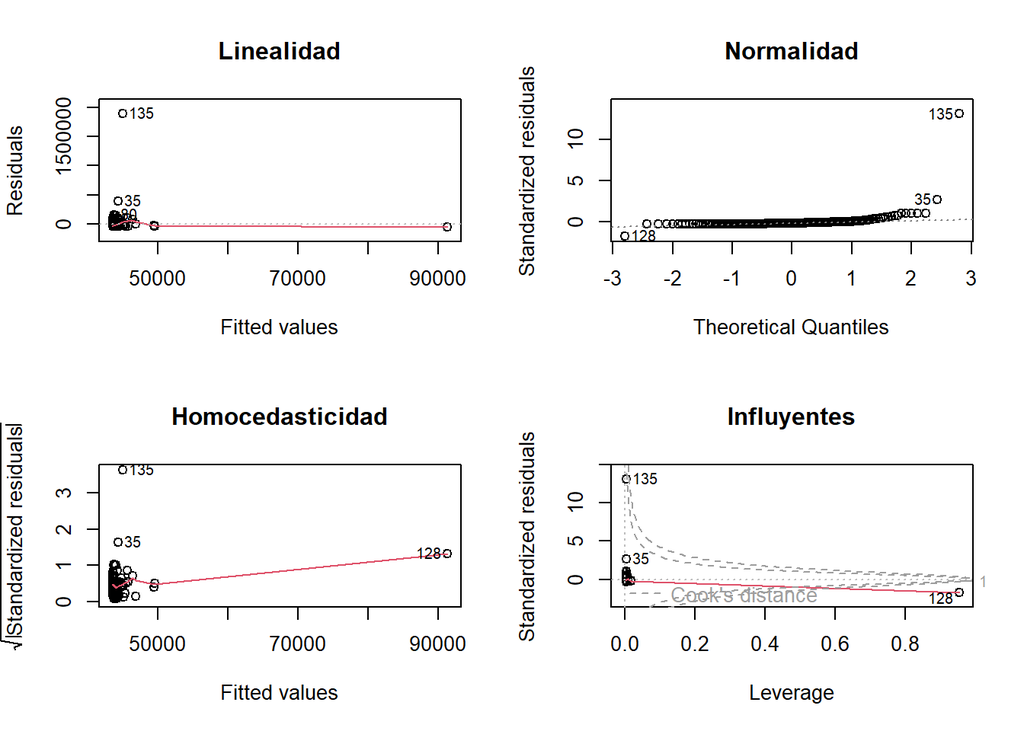

```r
par(mfrow = c(2, 2))
plot(rl1, 1,caption = '');title(main="Linealidad")
plot(rl1, 2, caption = '');title(main="Normalidad")
plot(rl1, 3, caption = '');title(main="Homocedasticidad")
plot(rl1, 5, caption = '');title(main="Influyentes")
```

Para mejorar este modelo, podemos incluir la variable de control (“habil”)

```r
library(knitr)
library(modelsummary)

h1control=formula(casti~gas + habil)

rl2=lm(h1control, data = dataCGSE)

modelslm=list('OLS votantes de Castillo (1)'=rl1,'OLS votantes de Castillo (2'=rl2)
modelsummary(modelslm, title = "Regresiones Lineales",
             stars = TRUE,
             output = "kableExtra")
```

Regresiones Lineales

|  | OLS votantes de Castillo (1) | OLS votantes de Castillo (2 |
| --- | --- | --- |
| (Intercept) | 43534.236*** | 12076.167*** |
|  | (10500.202) | (1601.736) |
| gas | 0.026 | −0.001 |
|  | (0.078) | (0.012) |
| habil |  | 0.259*** |
|  |  | (0.003) |
| Num.Obs. | 196 | 196 |
| R2 | 0.001 | 0.978 |
| R2 Adj. | −0.005 | 0.978 |
| AIC | 5217.7 | 4472.6 |
| BIC | 5227.5 | 4485.7 |
| Log.Lik. | −2605.852 | −2232.276 |
| F | 0.112 | 4271.803 |
| RMSE | 143806.91 | 21380.24 |

+ p < 0.1, * p < 0.05, ** p < 0.01, *** p < 0.001

Se presenta una mejora en el R2 ajustado

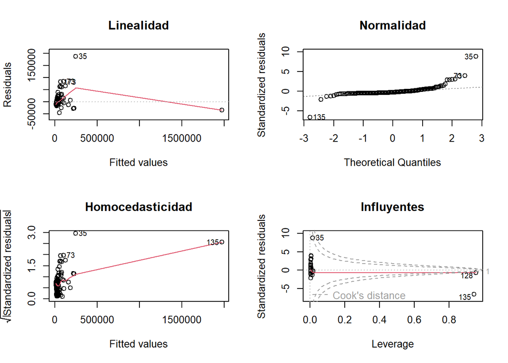

```r
par(mfrow = c(2, 2))
plot(rl2, 1,caption = '');title(main="Linealidad")
plot(rl2, 2, caption = '');title(main="Normalidad")
plot(rl2, 3, caption = '');title(main="Homocedasticidad")
plot(rl2, 5, caption = '');title(main="Influyentes")
```

Para entender mejor la naturaleza de la variable, hacemos un grafico de barras

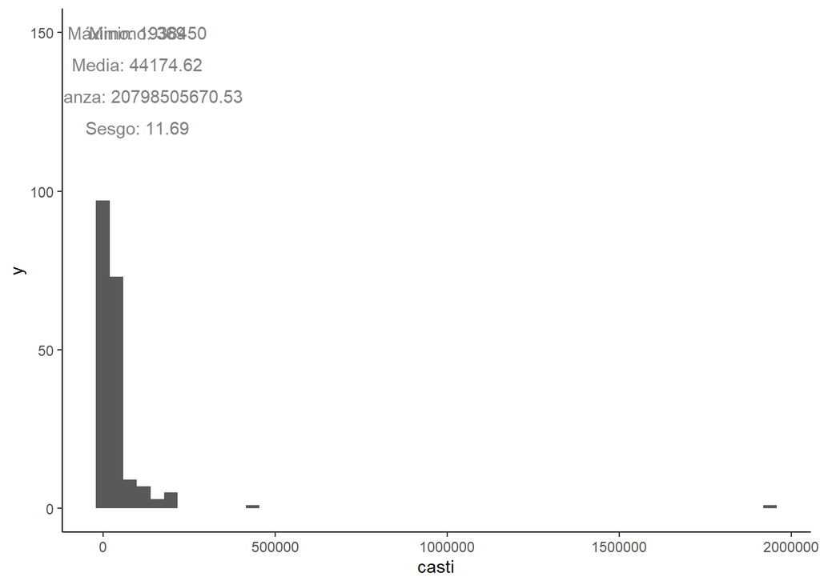

```r
library(ggplot2)
VarProv=dataCGSE$casti
descris=list(min=min(VarProv),
             max=max(VarProv),
             media=round(mean(VarProv),2),
             var=round(var(VarProv),2),
             asim=round(e1071::skewness(VarProv),2))

base=ggplot(data=dataCGSE, aes(x=casti)) + theme_classic()
hist=base + geom_histogram(bins=50)
histInfo=hist + annotate("text", x = 100000, y = 150,
                         color='grey50',
                       label = paste0("Minimo: ",descris$min))
histInfo = histInfo + annotate("text", x = 100000, y = 150,
                       color='grey50',
                       label = paste0("Máximo: ",descris$max))

histInfo = histInfo + annotate("text", x = 100000, y = 140,
                       color='grey50',
                       label = paste0("Media: ",descris$media))

histInfo = histInfo + annotate("text", x = 100000, y = 130,
                       color='grey50',
                       label = paste0("Varianza: ",descris$var))

histInfo = histInfo + annotate("text", x = 100000, y =120,
                       color='grey50',
                       label = paste0("Sesgo: ",descris$asim))

histInfo
```

Nos muestra un distribucion con sesgo positivo, recordandonos que nuestra variable dependiente representa valores enteros positivos

## REGRESION POISSON

Comparamos el resultado de la regresion lineal anterior controlada por los electores habiles con la regresion Poisson

```r
rp1=glm(h1, data = dataCGSE,
        offset=log(habil),
        family = poisson(link = "log"))

# displaying results
modelslmpoi=list('OLS votantes de Castillo (2)'=rl2,
                 'POISSON votantes de Castillo'=rp1)

modelsummary(modelslmpoi, title = "Regresiones OLS y Poisson",
             stars = TRUE,
             output = "kableExtra")
```

Regresiones OLS y Poisson

|  | OLS votantes de Castillo (2) | POISSON votantes de Castillo |
| --- | --- | --- |
| (Intercept) | 12076.167*** | −1.017*** |
|  | (1601.736) | (0.000) |
| gas | −0.001 | 0.000*** |
|  | (0.012) | (0.000) |
| habil | 0.259*** |  |
|  | (0.003) |  |
| Num.Obs. | 196 | 196 |
| R2 | 0.978 |  |
| R2 Adj. | 0.978 |  |
| AIC | 4472.6 | 160876328.1 |
| BIC | 4485.7 | 160876334.7 |
| Log.Lik. | −2232.276 | −80438162.051 |
| F | 4271.803 | 11244.777 |
| RMSE | 21380.24 | 56156.41 |

+ p < 0.1, * p < 0.05, ** p < 0.01, *** p < 0.001

Alteraremos nuestra primera hipotesis, siendo ahora: **A nivel provincial, la cantidad de personas que votaron por Pedro Castillo esta afectada por si cuentan con gas GLP, seguro de salud y acceso a la educacion**

```r
h2=formula(casti ~ gas+sis+acsedu)

rp2=glm(h2, data = dataCGSE, offset=log(habil),
        family = poisson(link = "log"))


modelsPois=list('POISSON votantes de Castillo (1)'=rp1,
                'POISSON votantes de Castillo (2)'=rp2)
modelsummary(modelsPois,
             title = "Regresiones Poisson anidadas",
             stars = TRUE,
             output = "kableExtra")
```

Regresiones Poisson anidadas

|  | POISSON votantes de Castillo (1) | POISSON votantes de Castillo (2) |
| --- | --- | --- |
| (Intercept) | −1.017*** | −1.039*** |
|  | (0.000) | (0.000) |
| gas | 0.000*** | 0.000*** |
|  | (0.000) | (0.000) |
| sis |  | 0.000*** |
|  |  | (0.000) |
| acsedu |  | 0.000*** |
|  |  | (0.000) |
| Num.Obs. | 196 | 196 |
| AIC | 160876328.1 | 160790071.6 |
| BIC | 160876334.7 | 160790084.7 |
| Log.Lik. | −80438162.051 | −80395031.808 |
| F | 11244.777 | 34452.273 |
| RMSE | 56156.41 | 39294.45 |

+ p < 0.1, * p < 0.05, ** p < 0.01, *** p < 0.001

## Equidispersion

Uno de los supuestos en la Regresión Poisson es que la media y la varianza sean iguales.

```r
overdispersion=AER::dispersiontest(rp2,alternative='greater')$ p.value<0.05
underdispersion=AER::dispersiontest(rp2,alternative='less')$ p.value<0.05
# tabla
testResult=as.data.frame(rbind(overdispersion,underdispersion))
names(testResult)='Es probable?'
testResult%>%kable(caption = "Test de Equidispersión")%>%kableExtra::kable_styling()
```

Test de Equidispersión

|  | Es probable? |
| --- | --- |
| overdispersion | TRUE |
| underdispersion | FALSE |

Haciendo la equidispersion nos damos cuenta que es improbable que la varianza sea igual a la media, por lo que intentaremos hacer la Quasi Poisson para tratar la presencia de la sobredispersion

## REGRESION QUASIPOISSON

```r
rqp = glm(h2, data = dataCGSE, offset=log(habil),
          family = quasipoisson(link = "log"))

modelsPQP=list('POISSON votantes de Castillo (2)'=rp2, 'QUASIPOISSON votantes de Castillo'=rqp)

modelsummary(modelsPQP, title = "Regresion Poisson y QuasiPoisson",
             stars = TRUE,
             output = "kableExtra")
```

Regresion Poisson y QuasiPoisson

|  | POISSON votantes de Castillo (2) | QUASIPOISSON votantes de Castillo |
| --- | --- | --- |
| (Intercept) | −1.039*** | −1.039*** |
|  | (0.000) | (0.029) |
| gas | 0.000*** | 0.000* |
|  | (0.000) | (0.000) |
| sis | 0.000*** | 0.000** |
|  | (0.000) | (0.000) |
| acsedu | 0.000*** | 0.000 |
|  | (0.000) | (0.000) |
| Num.Obs. | 196 | 196 |
| AIC | 160790071.6 |  |
| BIC | 160790084.7 |  |
| Log.Lik. | −80395031.808 |  |
| F | 34452.273 | 5.949 |
| RMSE | 39294.45 | 39294.45 |

+ p < 0.1, * p < 0.05, ** p < 0.01, *** p < 0.001

Nos muestra que los coeficientes son los mismos para ambos modelos.

Sin embargo (por recomendacion del profesor), usaremos la regresion Binomial Negativa como otra forma de tratar la sobredispersion, ademas porque es la mas utilizada para estos casos

## REGRESION BINOMIAL NEGATIVA

```r
h2off=formula(casti~gas + sis + acsedu + offset(log(habil)))
rbn=MASS::glm.nb(h2off,data=dataCGSE)

summary(rbn)
```

```
##
## Call:
## MASS::glm.nb(formula = h2off, data = dataCGSE, init.theta = 8.611336358,
##     link = log)
##
## Deviance Residuals:
##     Min       1Q   Median       3Q      Max
## -4.7852  -0.6969  -0.0637   0.5161   1.8346
##
## Coefficients:
##               Estimate Std. Error z value Pr(>|z|)
## (Intercept) -7.904e-01  3.071e-02 -25.737   <2e-16 ***
## gas          4.441e-07  1.109e-06   0.400    0.689
## sis         -8.028e-07  7.209e-07  -1.114    0.265
## acsedu       2.494e-07  9.529e-07   0.262    0.793
## ---
## Signif. codes:  0 '***' 0.001 '**' 0.01 '*' 0.05 '.' 0.1 ' ' 1
##
## (Dispersion parameter for Negative Binomial(8.6113) family taken to be 1)
##
##     Null deviance: 202.42  on 195  degrees of freedom
## Residual deviance: 199.87  on 192  degrees of freedom
## AIC: 4026.7
##
## Number of Fisher Scoring iterations: 1
##
##
##               Theta:  8.611
##           Std. Err.:  0.855
##
##  2 x log-likelihood:  -4016.723
```

```r
modelsQP_BN=list('POISSON votantes de Castillo (2)'=rp2,
                 'QuasiPoisson votantes de Castillo (2)'=rqp,
                 'Binomial Negativa votantes de Castillo (2)'=rbn)

f <- function(x) format(x, digits = 4, scientific = FALSE)
modelsummary(modelsQP_BN,fmt=f,
             exponentiate = T,
             statistic = 'conf.int',
             title = "EXP() de la Regresiones Poisson, Quasi Poisson  y Binomial Negativa",
             stars = TRUE,
             output = "kableExtra")
```

EXP() de la Regresiones Poisson, Quasi Poisson y Binomial Negativa

|  | POISSON votantes de Castillo (2) | QuasiPoisson votantes de Castillo (2) | Binomial Negativa votantes de Castillo (2) |
| --- | --- | --- | --- |
| (Intercept) | 0.3538*** | 0.3538*** | 0.4537*** |
|  | [0.3535, 0.3541] | [0.3343, 0.3742] | [0.4271, 0.4822] |
| gas | 1.0000*** | 1.0000* | 1.0000 |
|  | [1.0000, 1.0000] | [1.0000, 1.0000] | [1.0000, 1.0000] |
| sis | 1.0000*** | 1.0000** | 1.0000 |
|  | [1.0000, 1.0000] | [1.0000, 1.0000] | [1.0000, 1.0000] |
| acsedu | 1.0000*** | 1.0000 | 1.0000 |
|  | [1.0000, 1.0000] | [1.0000, 1.0000] | [1.0000, 1.0000] |
| Num.Obs. | 196 | 196 | 196 |
| AIC | 160790071.6 |  | 4026.7 |
| BIC | 160790084.7 |  | 4043.1 |
| Log.Lik. | −80395031.808 |  | −2008.361 |
| F | 34452.273 | 5.949 | 0.929 |
| RMSE | 39294.45 | 39294.45 | 117675.53 |

+ p < 0.1, * p < 0.05, ** p < 0.01, *** p < 0.001

# Comparacion de modelos

Usamos anova para la comparacion

```r
anova(rp2,rqp,rbn, test = "Chisq") %>%
kable(caption = "Tabla ANOVA para comparar modelos")%>%kableExtra::kable_styling(full_width = FALSE)
```

Tabla ANOVA para comparar modelos

| Resid. Df | Resid. Dev | Df | Deviance | Pr(>Chi) |
| --- | --- | --- | --- | --- |
| 192 | 1054200.7853 | NA | NA | NA |
| 192 | 1054200.7853 | 0 | 0 | NA |
| 192 | 199.8725 | 0 | 1054001 | NA |

[figure not shown]

```r
library(ggplot2)
dotwhisker::dwplot(list(Poisson=rqp,CuasiPoisso=rqp,BinomialNegativa=rbn),exp=T) + scale_y_discrete(labels=c("gas","seguro de salud", "acceso a educacion")) + scale_color_discrete(name="Modelos para:\nVotantes por Pedro Castillo") + geom_vline(
           xintercept = 1,
           colour = "grey60",
           linetype = 2
       )
```

.

.

# Regresion - MARIA HERRARA

```r
library(rio)
lkXLSX="https://github.com/MajoMurillo/Estadistica2---Trabajo/blob/main/indeppp.xlsx?raw=true"
indps=import(lkXLSX)
```

```r
lkXLSY="https://github.com/MajoMurillo/Estadistica2---Trabajo/raw/main/dependiente2.csv"
dep=import(lkXLSY)
```

```r
str(dep)
```

```
## 'data.frame':    196 obs. of  3 variables:
##  $ Provincia: chr  "Bagua" "Bongara" "Chachapoyas" "Condorcanqui" ...
##  $ casti    : int  25980 8374 15671 14024 12606 7967 36540 2325 5056 2860 ...
##  $ habil    : int  62110 20917 40752 38273 35017 22886 86231 5817 10921 5968 ...
```

```r
dep$casti=as.numeric(dep$casti)
```

```r
dep$habil=as.numeric(dep$habil)
```

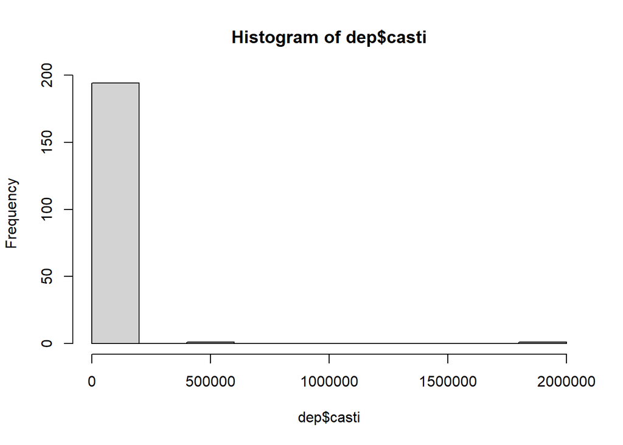

```r
hist(dep$casti)
```

Vemos que tiene una asimetría positiva marcada

```r
indps$Código=NULL
```

```r
library(stringr)
library(magrittr) # para %>%
indps$depar=str_split(string = indps$Provincia,
                         pattern = ', provincia:',
                         simplify = T)[,1]

indps$provin=str_split(string = indps$Provincia,
                          pattern = ', provincia:',
                          simplify = T)[,2]
```

```r
indps$Provincia=NULL
```

```r
indps=indps[,c(10:16)]
```

```r
dep$Provincia =trimws(dep$Provincia,which=c("both"),whitespace = "[\\h\\v]") # el espacio en blanco se determina "\\h\\v", o también "\t\r\n"
```

```r
indps$provin =trimws(indps$prov,which=c("both"),whitespace = "[\\h\\v]") # el espacio en blanco se determina "\\h\\v", o también "\t\r\n"
```

```r
names(indps)[7]=c("Provincia")
```

```r
str(dep)
```

```
## 'data.frame':    196 obs. of  3 variables:
##  $ Provincia: chr  "Bagua" "Bongara" "Chachapoyas" "Condorcanqui" ...
##  $ casti    : num  25980 8374 15671 14024 12606 ...
##  $ habil    : num  62110 20917 40752 38273 35017 ...
```

```r
indps=indps[,c(7,6,1:5)]
```

```r
basefinal=merge(indps,dep)
```

```r
str(basefinal)
```

```
## 'data.frame':    193 obs. of  9 variables:
##  $ Provincia: chr  "Abancay" "Acobamba" "Acomayo" "Aija" ...
##  $ depar    : chr  "Apurímac" "Huancavelica" "Cusco" "Áncash" ...
##  $ Ln       : num  55045 30231 18698 2517 12869 ...
##  $ Luz      : num  29588 8968 5364 1528 20021 ...
##  $ LuzN     : num  3050 2256 1541 413 7946 ...
##  $ AgS      : num  28019 7308 5593 1392 10980 ...
##  $ AgN      : num  2583 1914 472 111 3316 ...
##  $ casti    : num  43244 19060 13 2325 37196 ...
##  $ habil    : num  82538 33498 19229 5817 90033 ...
```

```r
names(basefinal)
```

```
## [1] "Provincia" "depar"     "Ln"        "Luz"       "LuzN"      "AgS"
## [7] "AgN"       "casti"     "habil"
```

Número de personas que votaron por Castillo –> VD Personas que tienen Luz electrica en casa –> VI Personas que tienen Agua en casa –> VI Etniticidad –>VI

Regresión:

A nivel provincial, el voto hacia el postulante a presidencia Castillo está afectada por el acceso a bienes básicos como luz

```r
library(knitr)
library(modelsummary)

h1=formula(casti~Luz)

rl1=lm(h1, data = basefinal)

model1=list('OLS asegurados (I)'=rl1)
modelsummary(model1, title = "Resumen de Regresion Lineal",
             stars = TRUE,
             output = "kableExtra")
```

Resumen de Regresion Lineal

|  | OLS asegurados (I) |
| --- | --- |
| (Intercept) | 11995.834*** |
|  | (1501.760) |
| Luz | 0.939*** |
|  | (0.010) |
| Num.Obs. | 193 |
| R2 | 0.980 |
| R2 Adj. | 0.980 |
| AIC | 4381.5 |
| BIC | 4391.3 |
| Log.Lik. | −2187.771 |
| F | 9522.276 |
| RMSE | 20265.22 |

+ p < 0.1, * p < 0.05, ** p < 0.01, *** p < 0.001

```r
summary(rl1)
```

```
##
## Call:
## lm(formula = h1, data = basefinal)
##
## Residuals:
##    Min     1Q Median     3Q    Max
## -42273  -9441  -5629   3762 171295
##
## Coefficients:
##              Estimate Std. Error t value Pr(>|t|)
## (Intercept) 1.200e+04  1.502e+03   7.988 1.26e-13 ***
## Luz         9.395e-01  9.628e-03  97.582  < 2e-16 ***
## ---
## Signif. codes:  0 '***' 0.001 '**' 0.01 '*' 0.05 '.' 0.1 ' ' 1
##
## Residual standard error: 20370 on 191 degrees of freedom
## Multiple R-squared:  0.9803, Adjusted R-squared:  0.9802
## F-statistic:  9522 on 1 and 191 DF,  p-value: < 2.2e-16
```

Vemos que la variable se valida (p-value menor a 0.05) y el R es alto, pero hacemos más pruebas, por ello procedemos a los supuestos:

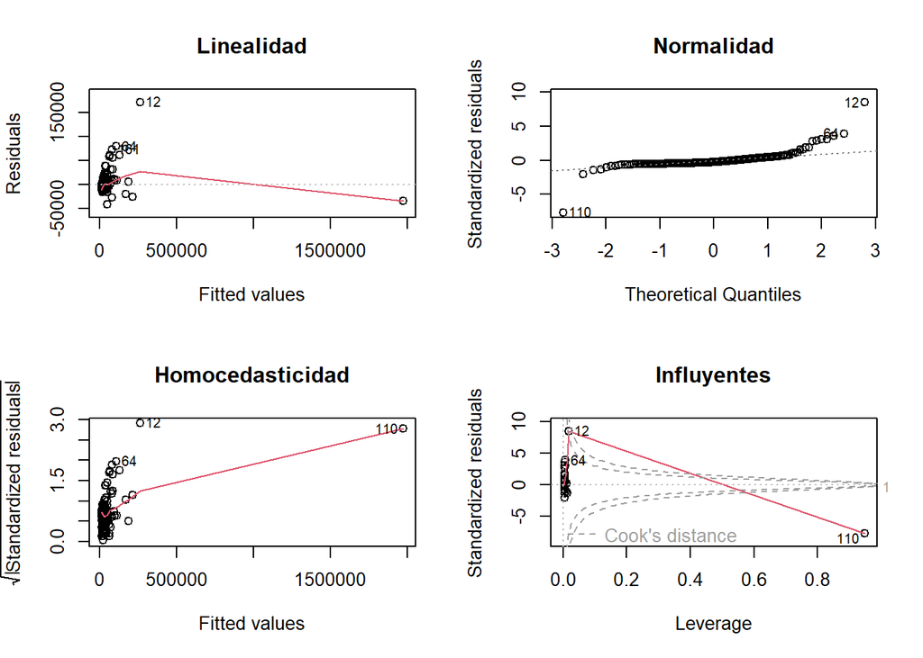

```r
par(mfrow = c(2, 2))
plot(rl1, 1,caption = '');title(main="Linealidad")
plot(rl1, 2, caption = '');title(main="Normalidad")
plot(rl1, 3, caption = '');title(main="Homocedasticidad")
plot(rl1, 5, caption = '');title(main="Influyentes")
```

Vemos que la linealidad esta cayendo, igualmente vemos casos atípicos y la homocedasticidad no cumple la recta. Por lo tanto vemos que los supuestos de la RLM caen.

Agregamos la variable habil(como variable control y hacemos otro RLM):

```r
library(knitr)
library(modelsummary)

h1control=formula(casti~Luz + habil)

rl2=lm(h1control, data = basefinal)

modelslm=list('OLS votos casti (I)'=rl1,'OLS votos casti (II)'=rl2)
modelsummary(modelslm, title = "Regresiones Lineales",
             stars = TRUE,
             output = "kableExtra")
```

Regresiones Lineales

|  | OLS votos casti (I) | OLS votos casti (II) |
| --- | --- | --- |
| (Intercept) | 11995.834*** | 11768.166*** |
|  | (1501.760) | (1437.724) |
| Luz | 0.939*** | 2.683*** |
|  | (0.010) | (0.404) |
| habil |  | −0.483*** |
|  |  | (0.112) |
| Num.Obs. | 193 | 193 |
| R2 | 0.980 | 0.982 |
| R2 Adj. | 0.980 | 0.982 |
| AIC | 4381.5 | 4365.4 |
| BIC | 4391.3 | 4378.5 |
| Log.Lik. | −2187.771 | −2178.724 |
| F | 9522.276 | 5211.024 |
| RMSE | 20265.22 | 19337.25 |

+ p < 0.1, * p < 0.05, ** p < 0.01, *** p < 0.001

Aunque el poder explicativo no aumento, podemos ver una posible multicolinealidad.

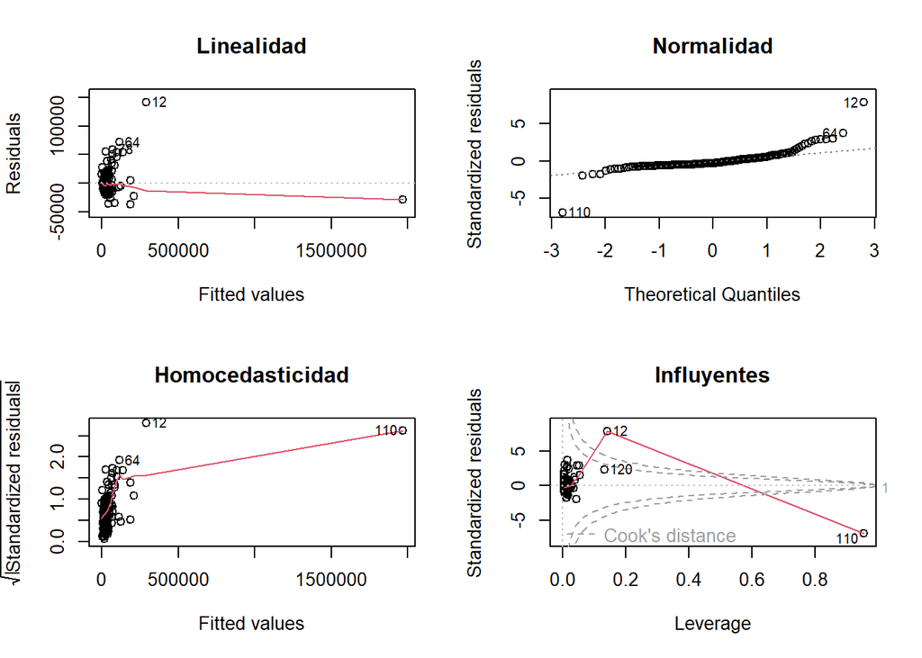

```r
par(mfrow = c(2, 2))
plot(rl2, 1,caption = '');title(main="Linealidad")
plot(rl2, 2, caption = '');title(main="Normalidad")
plot(rl2, 3, caption = '');title(main="Homocedasticidad")
plot(rl2, 5, caption = '');title(main="Influyentes")
```

Vemos que aún fallan los supuestos , por lo que procedemos a hacer una revisión gráfica:

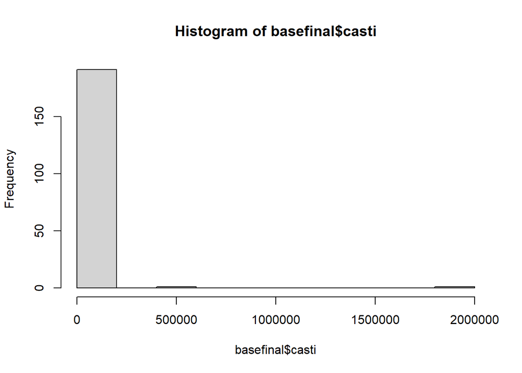

```r
hist(basefinal$casti)
```

```r
summary(basefinal$casti)
```

```
##    Min. 1st Qu.  Median    Mean 3rd Qu.    Max.
##      13    8579   20001   43636   39090 1938450
```

```r
rp1=glm(h1, data = basefinal,
        offset=log(habil), #exposure
        family = poisson(link = "log"))

# displaying results
modelslmpoi=list('OLS  (II)'=rl2,
                 'POISSON '=rp1)

modelsummary(modelslmpoi, title = "Regresiones OLS y Poisson",
             stars = TRUE,
             output = "kableExtra")
```

Regresiones OLS y Poisson

|  | OLS (II) | POISSON |
| --- | --- | --- |
| (Intercept) | 11768.166*** | −0.873*** |
|  | (1437.724) | (0.000) |
| Luz | 2.683*** | 0.000*** |
|  | (0.404) | (0.000) |
| habil | −0.483*** |  |
|  | (0.112) |  |
| Num.Obs. | 193 | 193 |
| R2 | 0.982 |  |
| R2 Adj. | 0.982 |  |
| AIC | 4365.4 | 155991169.8 |
| BIC | 4378.5 | 155991176.3 |
| Log.Lik. | −2178.724 | −77995582.909 |
| F | 5211.024 | 341931.450 |
| RMSE | 19337.25 | 18696.47 |

+ p < 0.1, * p < 0.05, ** p < 0.01, *** p < 0.001

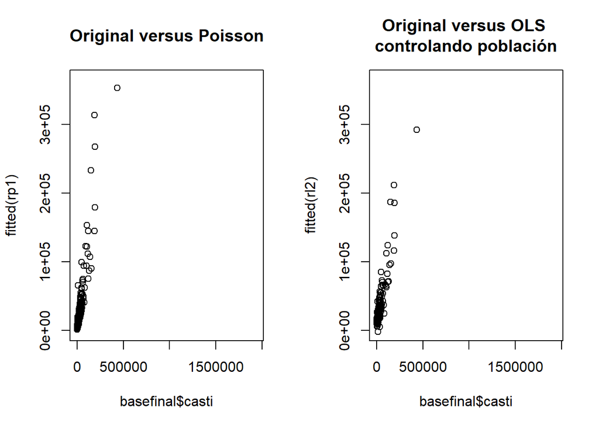

```r
par(mfrow = c(1, 2))  # divide screen 1 row 2 columns
plot(basefinal$casti,fitted(rp1),ylim=c(0,365000));title(main="Original versus Poisson")
plot(basefinal$casti,fitted(rl2),ylim=c(0,365000));title(main="Original versus OLS \ncontrolando población")
```

```r
names(basefinal)
```

```
## [1] "Provincia" "depar"     "Ln"        "Luz"       "LuzN"      "AgS"
## [7] "AgN"       "casti"     "habil"
```

```r
h2=formula(casti~Luz + AgS + Ln)

rp2=glm(h2, data = basefinal, offset=log(habil),
        family = poisson(link = "log"))


modelsPois=list('POISSON votos casti (I)'=rp1,
                'POISSON votos casti (II)'=rp2)
modelsummary(modelsPois,
             title = "Regresiones Poisson anidadas",
             stars = TRUE,
             output = "kableExtra")
```

Regresiones Poisson anidadas

|  | POISSON votos casti (I) | POISSON votos casti (II) |
| --- | --- | --- |
| (Intercept) | −0.873*** | −0.923*** |
|  | (0.000) | (0.001) |
| Luz | 0.000*** | 0.000*** |
|  | (0.000) | (0.000) |
| AgS |  | 0.000*** |
|  |  | (0.000) |
| Ln |  | 0.000*** |
|  |  | (0.000) |
| Num.Obs. | 193 | 193 |
| AIC | 155991169.8 | 155601895.2 |
| BIC | 155991176.3 | 155601908.3 |
| Log.Lik. | −77995582.909 | −77800943.603 |
| F | 341931.450 | 258227.365 |
| RMSE | 18696.47 | 10949.49 |

+ p < 0.1, * p < 0.05, ** p < 0.01, *** p < 0.001

```r
overdispersion=AER::dispersiontest(rp2,alternative='greater')$ p.value<0.05
underdispersion=AER::dispersiontest(rp2,alternative='less')$ p.value<0.05
# tabla
testResult=as.data.frame(rbind(overdispersion,underdispersion))
names(testResult)='Es probable?'
testResult%>%kable(caption = "Test de Equidispersión")%>%kableExtra::kable_styling()
```

Test de Equidispersión

|  | Es probable? |
| --- | --- |
| overdispersion | TRUE |
| underdispersion | FALSE |

Hay sobredispersión por lo que procedemos a usar la binomial negativa.

```r
rqp = glm(h2, data = basefinal, offset=log(habil),
          family = quasipoisson(link = "log"))

modelsPQP=list('POISSON votos casti (II)'=rp2,'QUASIPOISSON votos casti (II)'=rqp)

modelsummary(modelsPQP, title = "Regresiones Poisson y QuasiPoisson",
             stars = TRUE,
             output = "kableExtra")
```

Regresiones Poisson y QuasiPoisson

|  | POISSON votos casti (II) | QUASIPOISSON votos casti (II) |
| --- | --- | --- |
| (Intercept) | −0.923*** | −0.923*** |
|  | (0.001) | (0.023) |
| Luz | 0.000*** | 0.000*** |
|  | (0.000) | (0.000) |
| AgS | 0.000*** | 0.000** |
|  | (0.000) | (0.000) |
| Ln | 0.000*** | 0.000*** |
|  | (0.000) | (0.000) |
| Num.Obs. | 193 | 193 |
| AIC | 155601895.2 |  |
| BIC | 155601908.3 |  |
| Log.Lik. | −77800943.603 |  |
| F | 258227.365 | 143.980 |
| RMSE | 10949.49 | 10949.49 |

+ p < 0.1, * p < 0.05, ** p < 0.01, *** p < 0.001

```r
library(arm)
cbind(coefPoi=coef(rp2),coefQuasiPoi=coef(rqp))
```

```
##                   coefPoi  coefQuasiPoi
## (Intercept) -9.234752e-01 -9.234752e-01
## Luz         -7.552308e-06 -7.552308e-06
## AgS          6.562992e-06  6.562992e-06
## Ln           4.727818e-06  4.727818e-06
```

```r
cbind(sePoi=se.coef(rp2),seQuasiPoi=se.coef(rqp))
```

```
##                    sePoi   seQuasiPoi
## (Intercept) 5.313366e-04 2.250191e-02
## Luz         4.760398e-08 2.016011e-06
## AgS         5.461933e-08 2.313109e-06
## Ln          8.436558e-09 3.572852e-07
```

```r
summary(rqp)$dispersion; summary(rp2)$dispersion
```

```
## [1] 1793.492
```

```
## [1] 1
```

```r
modelsQPexp=list('QuasiPoisson votos casti (II) exponenciado'=rqp)

f <- function(x) format(x, digits = 4, scientific = FALSE)
modelsummary(modelsQPexp,fmt=f,
             exponentiate = T,
             statistic = 'conf.int',
             title = "EXP() de la Regresión Quasi Poisson (II) para Interpretación",
             stars = TRUE,
             output = "kableExtra")
```

EXP() de la Regresión Quasi Poisson (II) para Interpretación

|  | QuasiPoisson votos casti (II) exponenciado |
| --- | --- |
| (Intercept) | 0.3971*** |
|  | [0.3799, 0.4149] |
| Luz | 1.0000*** |
|  | [1.0000, 1.0000] |
| AgS | 1.0000** |
|  | [1.0000, 1.0000] |
| Ln | 1.0000*** |
|  | [1.0000, 1.0000] |
| Num.Obs. | 193 |
| Log.Lik. |  |
| F | 143.980 |
| RMSE | 10949.49 |

+ p < 0.1, * p < 0.05, ** p < 0.01, *** p < 0.001

```r
h2off=formula(casti~ + Luz+ Ln+ AgS + offset(log(habil)))
rbn=glm.nb(h2off,data=basefinal)

modelsQP_BN=list('Poisson asegurados (II)'=rp2,
                 'QuasiPoisson asegurados (II)'=rqp,
                 'Binomial Negativa asegurados (II)'=rbn)

f <- function(x) format(x, digits = 4, scientific = FALSE)
modelsummary(modelsQP_BN,fmt=f,
             exponentiate = T,
             statistic = 'conf.int',
             title = "EXP() de la Regresiones Poisson, Quasi Poisson  y Binomial Negativa",
             stars = TRUE,
             output = "kableExtra")
```

EXP() de la Regresiones Poisson, Quasi Poisson y Binomial Negativa

|  | Poisson asegurados (II) | QuasiPoisson asegurados (II) | Binomial Negativa asegurados (II) |
| --- | --- | --- | --- |
| (Intercept) | 0.3971*** | 0.3971*** | 0.4109*** |
|  | [0.3967, 0.3976] | [0.3799, 0.4149] | [0.386, 0.4378] |
| Luz | 1.0000*** | 1.0000*** | 1.0000* |
|  | [1.0000, 1.0000] | [1.0000, 1.0000] | [1.000, 1.0000] |
| AgS | 1.0000*** | 1.0000** | 1.0000+ |
|  | [1.0000, 1.0000] | [1.0000, 1.0000] | [1.000, 1.0000] |
| Ln | 1.0000*** | 1.0000*** | 1.0000*** |
|  | [1.0000, 1.0000] | [1.0000, 1.0000] | [1.000, 1.0000] |
| Num.Obs. | 193 | 193 | 193 |
| AIC | 155601895.2 |  | 3972.5 |
| BIC | 155601908.3 |  | 3988.9 |
| Log.Lik. | −77800943.603 |  | −1981.271 |
| F | 258227.365 | 143.980 | 20.182 |
| RMSE | 10949.49 | 10949.49 | 22582.72 |

+ p < 0.1, * p < 0.05, ** p < 0.01, *** p < 0.001

```r
anova(rp2,rqp,rbn, test = "Chisq") %>%
kable(caption = "Tabla ANOVA para comparar modelos")%>%kableExtra::kable_styling(full_width = FALSE)
```

Tabla ANOVA para comparar modelos

| Resid. Df | Resid. Dev | Df | Deviance | Pr(>Chi) |
| --- | --- | --- | --- | --- |
| 189 | 367015.3178 | NA | NA | NA |
| 189 | 367015.3178 | 0 | 0.0 | NA |
| 189 | 200.1307 | 0 | 366815.2 | NA |

.

.

# Regresion - ANGELO PALOMINO

```r
library(rio)
link="https://github.com/MajoMurillo/Estadistica2---Trabajo/blob/main/base%20de%20datos-Anelo.xlsx?raw=true"
data=import(link)
```

```r
library(summarytools)
library(kableExtra)
dfSummary(data,
          plain.ascii  = FALSE,
          varnumbers = FALSE,
          style        = "grid",
          graph.col=F,
          na.col    = FALSE) %>%
    kable(caption = "Descriptivos Univariados")%>%
    kable_styling(full_width = F)
```

```
## data was converted to a data frame
```

Descriptivos Univariados

| Variable | Stats / Values | Freqs (% of Valid) | Valid |
| --- | --- | --- | --- |
| Provincia [character] | 1. Abancay 2. Acobamba 3. Acomayo 4. Aija 5. Alto Amazonas 6. Ambo 7. Andahuaylas 8. Angaraes 9. Anta 10. Antabamba [ 186 others ] | 1 ( 0.5%) 1 ( 0.5%) 1 ( 0.5%) 1 ( 0.5%) 1 ( 0.5%) 1 ( 0.5%) 1 ( 0.5%) 1 ( 0.5%) 1 ( 0.5%) 1 ( 0.5%) \186 (94.9%) | 196 (100.0%) |
| casti [numeric] | Mean (sd) : 44110.2 (144233.9) min < med < max: 12.6 < 19896 < 1938450 IQR (CV) : 30502 (3.3) | 196 distinct values | 196 (100.0%) |
| habil [numeric] | Mean (sd) : 123891.5 (549863.7) min < med < max: 3041 < 45547 < 7558581 IQR (CV) : 70165.2 (4.4) | 196 distinct values | 196 (100.0%) |
| Jóvenes (18 - 29 años) [numeric] | Mean (sd) : 29935 (133310.2) min < med < max: 489 < 9859.5 < 1823609 IQR (CV) : 16398.8 (4.5) | 196 distinct values | 196 (100.0%) |
| Sí tiene conexión a internet [numeric] | Mean (sd) : 11807.1 (84911.1) min < med < max: 3 < 659.5 < 1171306 IQR (CV) : 3352.8 (7.2) | 184 distinct values | 196 (100.0%) |
| No tiene conexión a internet [numeric] | Mean (sd) : 30296.4 (87639.1) min < med < max: 685 < 14894.5 < 1182644 IQR (CV) : 20926.8 (2.9) | 196 distinct values | 196 (100.0%) |
| Ninguna [numeric] | Mean (sd) : 6022.2 (33240) min < med < max: 38 < 1424 < 458304 IQR (CV) : 3663.2 (5.5) | 187 distinct values | 196 (100.0%) |
| reliion [numeric] | Mean (sd) : 112326.7 (482136.9) min < med < max: 1856 < 39675.5 < 6602456 IQR (CV) : 60216.2 (4.3) | 196 distinct values | 196 (100.0%) |

```r
data$Provincia=as.factor(data$Provincia)
```

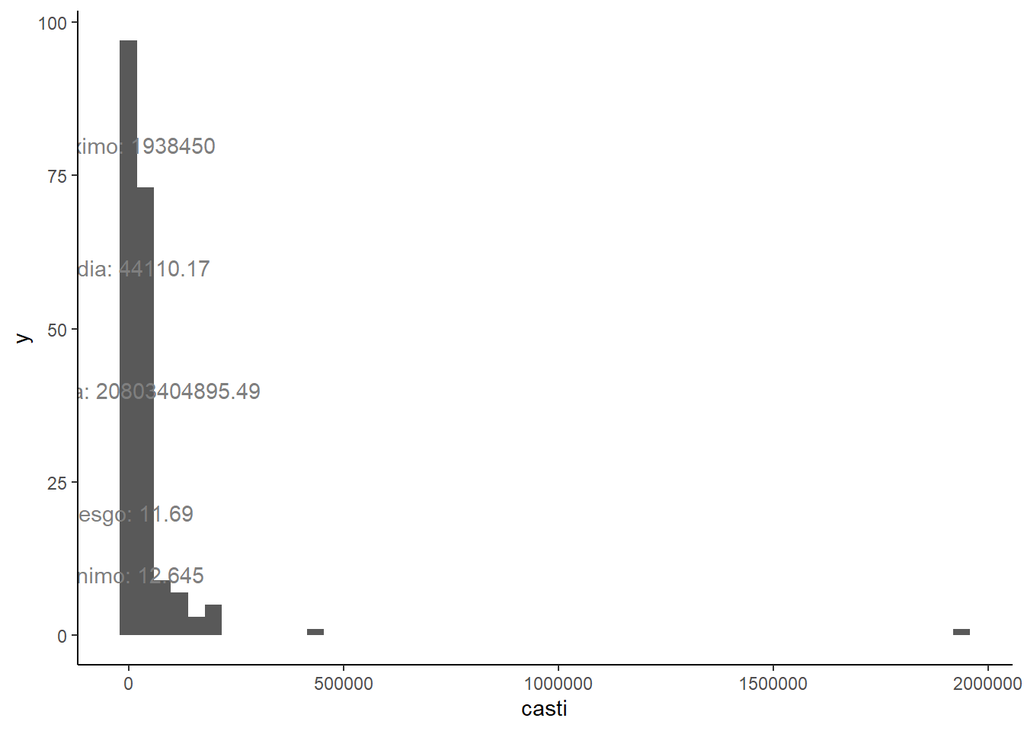

```r
library(ggplot2)
VarDep=data$casti
descris=list(min=min(VarDep),
             max=max(VarDep),
             media=round(mean(VarDep),2),
             var=round(var(VarDep),2),
             asim=round(e1071::skewness(VarDep),2))
base=ggplot(data=data, aes(x=casti)) + theme_classic()
hist=base + geom_histogram(bins=50)
histInfo=hist + annotate("text", x = 100 , y = 10 ,
                         color='grey50',
                       label = paste0("Minimo: ",descris$min))
histInfo = histInfo + annotate("text", x = 100 , y = 80 ,
                       color='grey50',
                       label = paste0("Máximo: ",descris$max))
histInfo = histInfo + annotate("text", x = 100 , y = 60 ,
                       color='grey50',
                       label = paste0("Media: ",descris$media))
histInfo = histInfo + annotate("text", x = 100 , y = 40 ,
                       color='grey50',
                       label = paste0("Varianza: ",descris$var))
histInfo = histInfo + annotate("text", x = 100 , y = 20 ,
                       color='grey50',
                       label = paste0("Sesgo: ",descris$asim))
histInfo
```

```r
h1=formula(data$casti~data$`Jóvenes (18 - 29 años)`+data$`Sí tiene conexión a internet`+data$`No tiene conexión a internet`+data$Ninguna+data$reliion)
rp1=glm(h1, data=data, offset = log(data$habil),
        family = poisson(link = "log"))
modelsPois=list('POISSON asegurados (I)'=rp1)
library(modelsummary)
modelsummary(modelsPois,
             title = "Regresiones Poisson anidadas",
             stars = TRUE,
             output = "kableExtra")
```

Regresiones Poisson anidadas

[output not shown]

+ p < 0.1, * p < 0.05, ** p < 0.01, *** p < 0.001

```r
overdispersion=AER::dispersiontest(rp1,alternative='greater')$ p.value<0.05
underdispersion=AER::dispersiontest(rp1,alternative='less')$ p.value<0.05
# tabla
testResult=as.data.frame(rbind(overdispersion,underdispersion))
names(testResult)='Es probable?'
testResult%>%kable(caption = "Test de Equidispersión")%>%kableExtra::kable_styling()
```

Test de Equidispersión

|  | Es probable? |
| --- | --- |
| overdispersion | TRUE |
| underdispersion | FALSE |

#binomial

```r
h2off=formula(data$casti~data$`Jóvenes (18 - 29 años)`+data$`Sí tiene conexión a internet`+data$`No tiene conexión a internet`+data$Ninguna+data$reliion+ offset(log(habil)))
library(MASS)
rbn=MASS::glm.nb(h2off,data=data)
summary(rbn)
```

```
##
## Call:
## MASS::glm.nb(formula = h2off, data = data, init.theta = 6.654621408,
##     link = log)
##
## Deviance Residuals:
##     Min       1Q   Median       3Q      Max
## -8.2233  -0.5464   0.0357   0.4712   1.9813
##
## Coefficients:
##                                       Estimate Std. Error z value Pr(>|z|)
## (Intercept)                         -8.460e-01  4.872e-02 -17.363  < 2e-16 ***
## data$`Jóvenes (18 - 29 años)`        4.490e-06  1.252e-05   0.359  0.71980
## data$`Sí tiene conexión a internet`  4.272e-05  9.485e-06   4.504 6.67e-06 ***
## data$`No tiene conexión a internet`  3.311e-05  7.901e-06   4.191 2.78e-05 ***
## data$Ninguna                        -2.014e-05  1.007e-05  -1.999  0.04556 *
## data$reliion                        -1.342e-05  4.136e-06  -3.246  0.00117 **
## ---
## Signif. codes:  0 '***' 0.001 '**' 0.01 '*' 0.05 '.' 0.1 ' ' 1
##
## (Dispersion parameter for Negative Binomial(6.6546) family taken to be 1)
##
##     Null deviance: 225.54  on 195  degrees of freedom
## Residual deviance: 203.16  on 190  degrees of freedom
## AIC: 4072.2
##
## Number of Fisher Scoring iterations: 1
##
##
##               Theta:  6.655
##           Std. Err.:  0.664
##
##  2 x log-likelihood:  -4058.219
```

```r
modelsQP_BN=list('Binomial Negativa asegurados (II)'=rbn)
f <- function(x) format(x, digits = 4, scientific = FALSE)
modelsummary(modelsQP_BN,fmt=f,
             exponentiate = T,
             statistic = 'conf.int',
             title = "EXP() de la Regresiones Poisson, Quasi Poisson  y Binomial Negativa",
             stars = TRUE,
             output = "kableExtra")
```

EXP() de la Regresiones Poisson, Quasi Poisson y Binomial Negativa

[output not shown]

+ p < 0.1, * p < 0.05, ** p < 0.01, *** p < 0.001